# Analysis of AR(p) Processes:

2025-07-27

# Introduction to AR Processes

Autoregressive (AR) processes are fundamental building blocks in time series analysis. An AR(p) process is defined as:

$$Y_t = \phi_0 + \phi_1 Y_{t-1} + \phi_2
Y_{t-2} + \ldots + \phi_p Y_{t-p} + u_t$$

where $u_t \sim WN(0, \sigma^2)$ (white noise).

## Key Properties

- **Stationarity**: Requires roots of characteristic equation outside unit circle
- **Autocorrelation**: Exponential decay (AR(1)) or sinusoidal patterns (AR(2))
- **Partial Autocorrelation**: Cuts off after lag p

# AR(1) Process Analysis

## Mathematical Foundation

An AR(1) process has the form:
$$Y_t =
\phi_0 + \phi_1 Y_{t-1} + u_t$$

**Stationarity condition**: $|\phi_1| < 1$

**Key properties**:

- Mean: $\mathbb{E}[Y_t] = \frac{\phi_0}{1-\phi_1}$
- Variance: $Var(Y_t) = \frac{\sigma^2}{1-\phi^2}$
- Autocorrelation: $\rho(Y_t, Y_{s}) = \phi^{|t-s|}$

## Simulation of Different AR(1) Processes

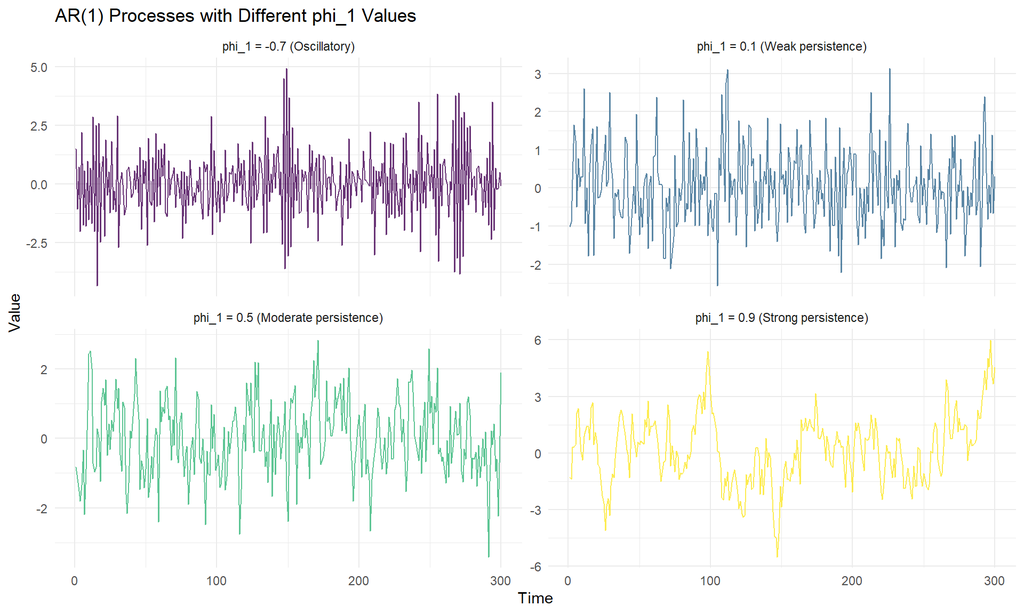

```r
# Function to simulate AR(1) process
simulate_ar1 <- function(n, phi, c = 0, sigma = 1) {
  y <- numeric(n)
  u <- rnorm(n, 0, sigma)

  # Starting value (unconditional mean)
  y[1] <- c / (1 - phi) + u[1] / sqrt(1 - phi^2)

  for (t in 2:n) {
    y[t] <- c + phi * y[t-1] + u[t]
  }

  return(y)
}

# Simulate different AR(1) processes
n <- 300
ar1_data <- tibble(
  time = rep(1:n, 4),
  series = rep(c("phi_1 = 0.9 (Strong persistence)",
                 "phi_1 = 0.5 (Moderate persistence)",
                 "phi_1 = -0.7 (Oscillatory)",
                 "phi_1 = 0.1 (Weak persistence)"), each = n),
  phi = rep(c(0.9, 0.5, -0.7, 0.1), each = n),
  y = c(simulate_ar1(n, 0.9),
        simulate_ar1(n, 0.5),
        simulate_ar1(n, -0.7),
        simulate_ar1(n, 0.1))
) |>
  as_tsibble(index = time, key = series)

# Plot AR(1) processes
p1 <- ar1_data |>
  ggplot(aes(x = time, y = y, color = series)) +
  geom_line(alpha = 0.8) +
  facet_wrap(~series, scales = "free_y", ncol = 2) +
  labs(title = "AR(1) Processes with Different phi_1 Values",
       x = "Time", y = "Value") +
  theme_minimal() +
  theme(legend.position = "none") +
  scale_color_viridis_d()

print(p1)
```

## AR(1) Autocorrelation Functions

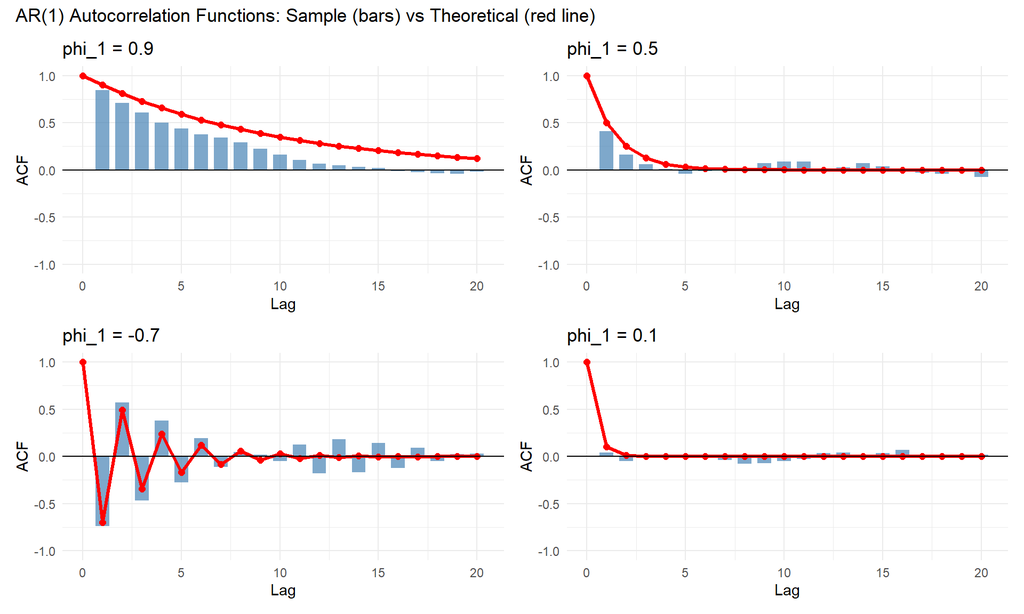

```r
# Calculate theoretical ACF for AR(1)
calculate_ar1_acf <- function(phi, max_lag = 20) {
  lags <- 0:max_lag
  acf_values <- phi^lags
  return(data.frame(lag = lags, acf = acf_values))
}

# Create ACF plots for different phi_1 values
phi_values <- c(0.9, 0.5, -0.7, 0.1)
acf_plots <- list()

for (i in 1:length(phi_values)) {
  phi <- phi_values[i]
  theoretical_acf <- calculate_ar1_acf(phi)

  # Get sample data for this phi
  sample_data <- ar1_data |>
    filter(phi == !!phi) |>
    as_tsibble(index = time)

  # Sample ACF
  sample_acf <- sample_data |> ACF(y, lag_max = 20)

  acf_plots[[i]] <- ggplot() +
    geom_col(data = sample_acf, aes(x = lag, y = acf),
             fill = "steelblue", alpha = 0.7, width = 0.7) +
    geom_line(data = theoretical_acf, aes(x = lag, y = acf),
              color = "red", linewidth = 1.2) +
    geom_point(data = theoretical_acf, aes(x = lag, y = acf),
               color = "red", size = 2) +
    labs(title = paste("phi_1 =", phi),
         x = "Lag", y = "ACF") +
    theme_minimal() +
    geom_hline(yintercept = 0, color = "black") +
    ylim(-1, 1)
}

# Arrange ACF plots
(acf_plots[[1]] + acf_plots[[2]]) / (acf_plots[[3]] + acf_plots[[4]]) +
  plot_annotation(title = "AR(1) Autocorrelation Functions: Sample (bars) vs Theoretical (red line)")
```

## AR(1) PACF and Stationarity

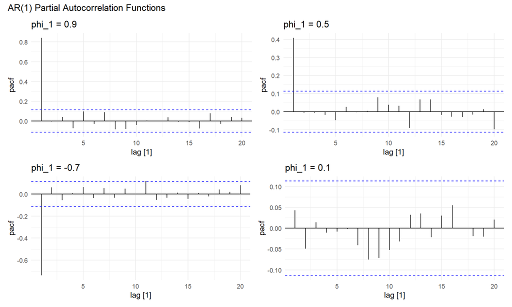

```r
# PACF for AR(1) processes
pacf_plots <- list()

for (i in 1:length(phi_values)) {
  phi <- phi_values[i]
  sample_data <- ar1_data |>
    filter(phi == !!phi) |>
    as_tsibble(index = time)

  pacf_plots[[i]] <- sample_data |>
    PACF(y, lag_max = 20) |>
    autoplot() +
    labs(title = paste("phi_1 =", phi)) +
    theme_minimal()
}

# Arrange PACF plots
(pacf_plots[[1]] + pacf_plots[[2]]) / (pacf_plots[[3]] + pacf_plots[[4]]) +
  plot_annotation(title = "AR(1) Partial Autocorrelation Functions")
```

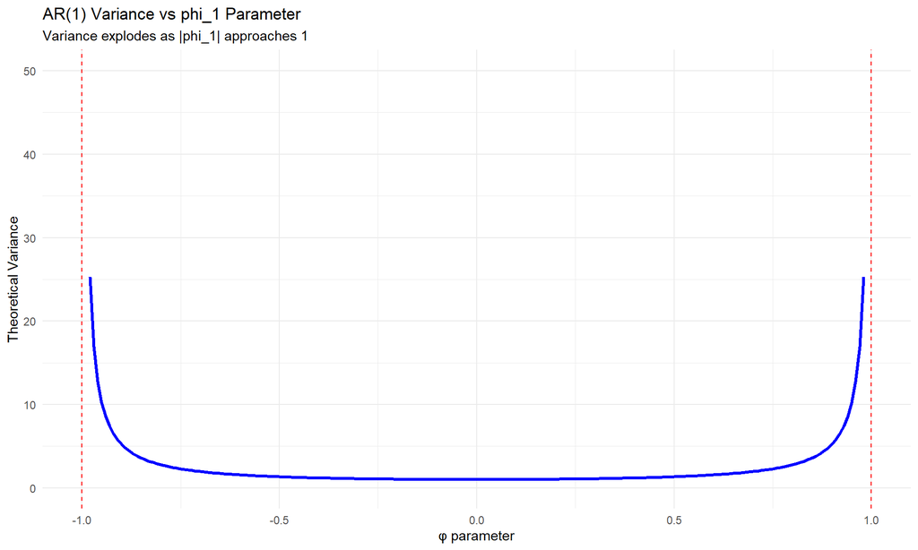

```r
# Stationarity visualization
phi_range <- seq(-0.99, 0.99, by = 0.01)
stationarity_data <- tibble(
  phi = phi_range,
  stationary = abs(phi) < 1,
  variance = ifelse(abs(phi) < 1, 1 / (1 - phi^2), NA)
)

p_stationarity <- ggplot(stationarity_data, aes(x = phi, y = variance)) +
  geom_line(color = "blue", linewidth = 1.2) +
  geom_vline(xintercept = c(-1, 1), color = "red", linetype = "dashed") +
  labs(title = "AR(1) Variance vs phi_1 Parameter",
       subtitle = "Variance explodes as |phi_1| approaches 1",
       x = "φ parameter", y = "Theoretical Variance") +
  theme_minimal() +
  ylim(0, 50)

print(p_stationarity)
```